# Species Accumulation CurvesArtenakkumulationskurven

Data Analysis in RDatenanalyse in R

Ecology Practicum - Day 2Okologie-Praktikum - Tag 2

2026-01-20

# Part 4: Building Accumulation CurvesTeil 4: Akkumulationskurven bauen

## Review from YesterdayWiederholung von gestern

**What is a species accumulation curve?**

- Shows how many species we find as we sample more plots
- Flattens because new species become rarer
- The asymptote estimates the total species count

**Was ist eine Artenakkumulationskurve?**

- Zeigt, wie viele Arten wir finden, wenn wir mehr Plots untersuchen
- Flacht ab, weil neue Arten seltener werden
- Die Asymptote schatzt die Gesamtartenzahl

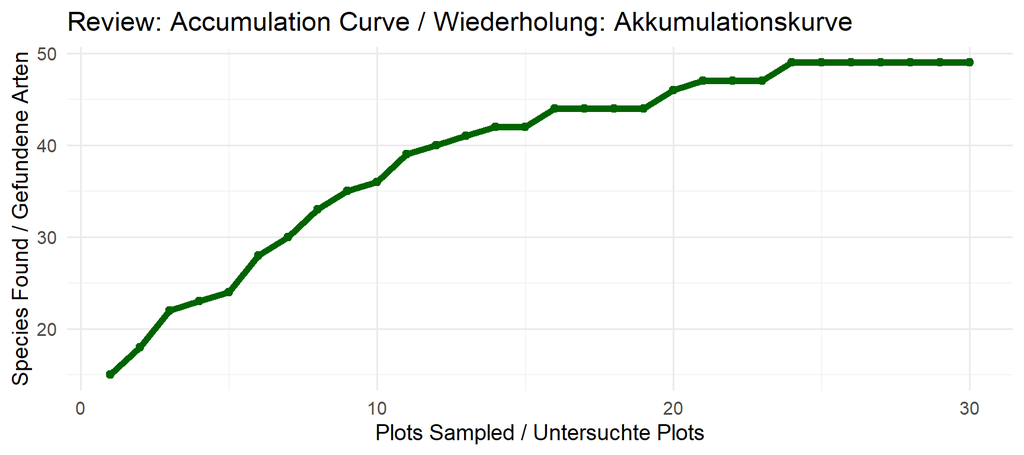

## Warm-up ExerciseWarm-up Ubung

```r
# Quick review: What does this code output?
# Schnelle Wiederholung: Was gibt dieser Code aus?

species_plot1 <- c("Beech", "Oak", "Spruce")
species_plot2 <- c("Oak", "Pine", "Linden")

# Combine both lists / Kombiniere beide Listen
all_species <- c(species_plot1, species_plot2)

# How many unique species? / Wie viele einzigartige Arten?
count <- length(unique(all_species))
print(count)  # ?
```

**Discuss in pairs (3 min):** Why is `unique()` important for accumulation curves?

**Diskutiert zu zweit (3 min):** Warum ist `unique()` wichtig fur Akkumulationskurven?

## Today: Building Curves in RHeute: Kurven in R bauen

**Goal:** Program an accumulation curve step by step in R.

**Why?** - Understand how the algorithm works - Reproducible analysis - Later: Compare native vs. alien

**Ziel:** Eine Akkumulationskurve Schritt fur Schritt in R programmieren.

**Warum?** - Verstehen, wie der Algorithmus funktioniert - Reproduzierbare Analyse - Spater: Vergleich heimisch vs. alien

## Understanding the AlgorithmDen Algorithmus verstehen

**The 5 Steps:**

1. **Choose starting point** - a random plot
2. **Count species** - how many species in this plot?
3. **Find next plot** - the geographically nearest
4. **Add new species** - only those we don’t have yet
5. **Repeat** - until all plots are visited

**Die 5 Schritte:**

1. **Startpunkt wahlen** - ein zufalliger Plot
2. **Arten zahlen** - wie viele Arten in diesem Plot?
3. **Nachsten Plot finden** - der geografisch nachste
4. **Neue Arten addieren** - nur die, die wir noch nicht haben
5. **Wiederholen** - bis alle Plots besucht sind

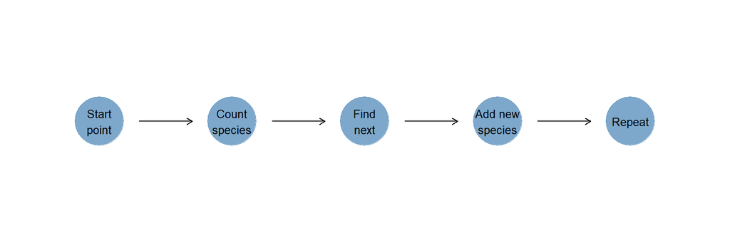

## Paper Exercise: Algorithm by HandPapierubung: Algorithmus per Hand

**Example Data (simplified):**

| Plot | X | Y | Species |
| --- | --- | --- | --- |
| A | 0 | 0 | Beech, Oak |
| B | 1 | 1 | Oak, Spruce |
| C | 3 | 0 | Beech, Pine |
| D | 1 | 3 | Linden, Oak |

**Task (10 min in pairs):**

1. Start at Plot A
2. Which plot is nearest? (Calculate distances!)
3. How many new species do you find?
4. Repeat until all plots are visited
5. Draw the curve on paper

**Beispiel-Daten (vereinfacht):**

| Plot | X | Y | Arten |
| --- | --- | --- | --- |
| A | 0 | 0 | Buche, Eiche |
| B | 1 | 1 | Eiche, Fichte |
| C | 3 | 0 | Buche, Kiefer |
| D | 1 | 3 | Linde, Eiche |

**Aufgabe (10 min in Zweiergruppen):**

1. Startet bei Plot A
2. Welcher Plot ist der nachste? (Berechnet Distanzen!)
3. Wie viele neue Arten findet ihr?
4. Wiederholt bis alle Plots besucht sind
5. Zeichnet die Kurve auf Papier

[figure not shown]

## Visualization: Spatial OrderVisualisierung: Raumliche Reihenfolge

[figure not shown]

## Discussion: Why Spatial Order?Diskussion: Warum raumliche Ordnung?

**Question:** What would change if we visited plots randomly?

**Hypotheses:** - Curve flatter or steeper? - More or less variance? - Biological interpretation?

**Answer:** Spatial autocorrelation! Nearby plots often have similar species. - **Nearest Neighbour** - finds new species slowly (conservative) - **Random** - finds new species faster (optimistic)

**Frage:** Was wurde sich andern, wenn wir die Plots zufallig besuchen?

**Hypothesen:** - Kurve flacher oder steiler? - Mehr oder weniger Varianz? - Biologische Interpretation?

**Antwort:** Raumliche Autokorrelation! Nahe Plots haben oft ahnliche Arten. - **Nearest Neighbour** - findet langsam neue Arten (konservativ) - **Zufallig** - findet schneller neue Arten (optimistisch)

## R Exercise: LoopsR Ubung: Schleifen

**Loops** repeat code multiple times - essential for our algorithm!

```r
# A simple for loop
for (i in 1:5) {
  print(i)
}

# Fill in the blanks!

# 1. Print numbers 1 to 10
for (i in ____) {
  print(____)
}

# 2. Iterate over letters
letters <- c("A", "B", "C", "D")
for (letter in ____) {
  print(paste("Plot", ____))
}

# 3. Build a vector with squares
squares <- c()
for (i in 1:10) {
  squares[i] <- ____^2
}
print(squares)
```

**Schleifen** wiederholen Code mehrmals - essentiell fur unseren Algorithmus!

```r
# Eine einfache for-Schleife
for (i in 1:5) {
  print(i)
}

# Luckentext: Fulle aus!

# 1. Drucke die Zahlen 1 bis 10
for (i in ____) {
  print(____)
}

# 2. Iteriere uber Buchstaben
buchstaben <- c("A", "B", "C", "D")
for (buchstabe in ____) {
  print(paste("Plot", ____))
}

# 3. Baue einen Vektor mit Quadratzahlen
quadrate <- c()
for (i in 1:10) {
  quadrate[i] <- ____^2
}
print(quadrate)
```

## Calculating DistanceDistanz berechnen

To find the “nearest plot”, we need the **Euclidean distance**.

**Formula:** $d = \sqrt{(x_2 - x_1)^2 + (y_2 - y_1)^2}$

```r
# Two points
point1 <- c(x = 10, y = 20)
point2 <- c(x = 13, y = 24)

# Euclidean distance
distance <- sqrt((point2["x"] - point1["x"])^2 +
                 (point2["y"] - point1["y"])^2)
print(distance)  # 5
```

Um den “nachsten Plot” zu finden, brauchen wir die **euklidische Distanz**.

**Formel:** $d = \sqrt{(x_2 - x_1)^2 + (y_2 - y_1)^2}$

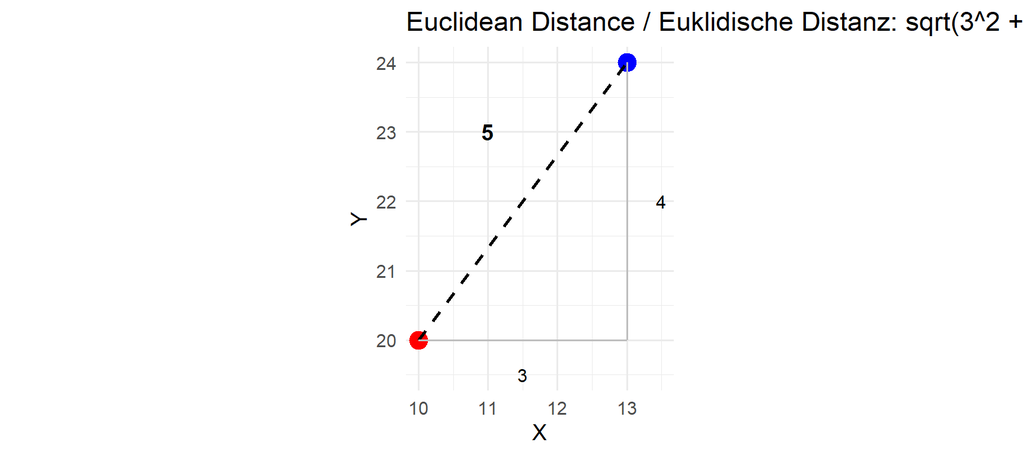

```r
# Zwei Punkte
punkt1 <- c(x = 10, y = 20)
punkt2 <- c(x = 13, y = 24)

# Euklidische Distanz
distanz <- sqrt((punkt2["x"] - punkt1["x"])^2 +
                (punkt2["y"] - punkt1["y"])^2)
print(distanz)  # 5
```

# Part 5: Analyzing Vegetation DataTeil 5: Vegetationsdaten analysieren

## Our Research QuestionUnsere Forschungsfrage

> **Do alien species accumulate differently than native species?**

**Hypotheses:** - H1: Aliens accumulate more slowly (fewer species overall) - H2: Aliens accumulate more evenly (less spatially clustered)

> **Akkumulieren Alien-Arten anders als heimische Arten?**

**Hypothesen:** - H1: Aliens akkumulieren langsamer (weniger Arten insgesamt) - H2: Aliens akkumulieren gleichmassiger (weniger raumlich geclustert)

## The Data: EVA DatabaseDie Daten: EVA-Datenbank

### What is EVA?

**European Vegetation Archive** - the largest vegetation database in Europe

| Property | Value |
| --- | --- |
| Plots | ~52,000 |
| Region | Austria |
| Time period | 1950-2023 |
| Native species | ~2,800 |
| Alien species | ~450 |

### Was ist EVA?

**European Vegetation Archive** - die grosste Vegetationsdatenbank Europas

| Eigenschaft | Wert |
| --- | --- |
| Plots | ~52.000 |
| Region | Osterreich |
| Zeitraum | 1950-2023 |
| Heimische Arten | ~2.800 |
| Alien-Arten | ~450 |

## EVA Data StructureEVA Datenstruktur

**Typical columns in EVA data:**

| Column | Meaning | Example |
| --- | --- | --- |
| `plot_id` | Unique plot number | “AT_2019_0042” |
| `x`, `y` | Coordinates (UTM) | 450123, 5230456 |
| `species` | Scientific name | “Fagus sylvatica” |
| `cover` | Cover percentage | 60 |
| `status` | Native/Alien status | “native” |
| `habitat` | Habitat type | “Forest” |
| `year` | Survey year | 2019 |

**Typische Spalten in EVA-Daten:**

| Spalte | Bedeutung | Beispiel |
| --- | --- | --- |
| `plot_id` | Eindeutige Plot-Nummer | “AT_2019_0042” |
| `x`, `y` | Koordinaten (UTM) | 450123, 5230456 |
| `species` | Artname (wissenschaftlich) | “Fagus sylvatica” |
| `cover` | Deckungsgrad (%) | 60 |
| `status` | Native/Alien Status | “native” |
| `habitat` | Habitattyp | “Wald” |
| `year` | Aufnahmejahr | 2019 |

## Native vs. Alien: DistributionHeimisch vs. Alien: Verteilung

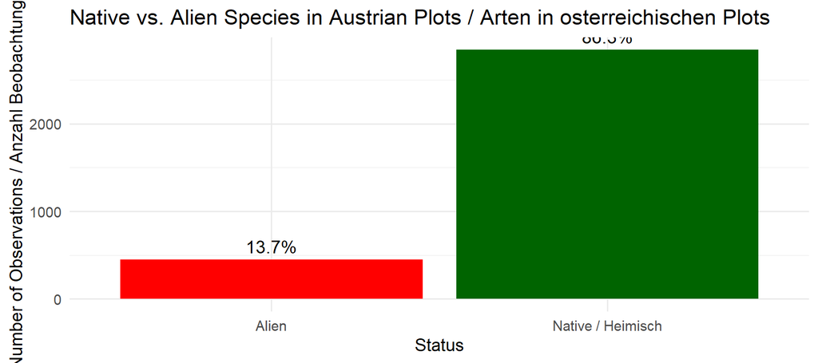

## R Exercise: Filtering DataR Ubung: Daten filtern

### Method 1: Square brackets [ ]

```r
# Example data
data <- data.frame(
  species = c("Oak", "Balsam", "Beech", "Goldenrod"),
  status = c("native", "alien", "native", "alien"),
  count = c(150, 45, 120, 30)
)

# 1. Only native species
native <- data[data$status == ____, ]

# 2. Only aliens
aliens <- data[data$____ == "alien", ]

# 3. Only species with more than 50 occurrences
frequent <- data[data$count ____ 50, ]

# 4. Native AND frequent
native_frequent <- data[data$status == "native" ____ data$count > 100, ]
```

### Methode 1: Eckige Klammern [ ]

```r
# Beispieldaten
daten <- data.frame(
  art = c("Eiche", "Springkraut", "Buche", "Goldrute"),
  status = c("native", "alien", "native", "alien"),
  anzahl = c(150, 45, 120, 30)
)

# 1. Nur heimische Arten
heimisch <- daten[daten$status == ____, ]

# 2. Nur Aliens
aliens <- daten[daten$____ == "alien", ]

# 3. Nur Arten mit mehr als 50 Vorkommen
haeufig <- daten[daten$anzahl ____ 50, ]

# 4. Heimisch UND haufig
heimisch_haeufig <- daten[daten$status == "native" ____ daten$anzahl > 100, ]
```

## Exploratory Data AnalysisExplorative Datenanalyse

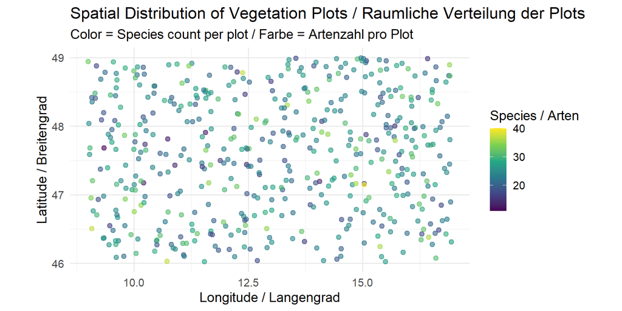

## Species Richness DistributionVerteilung der Artenzahl

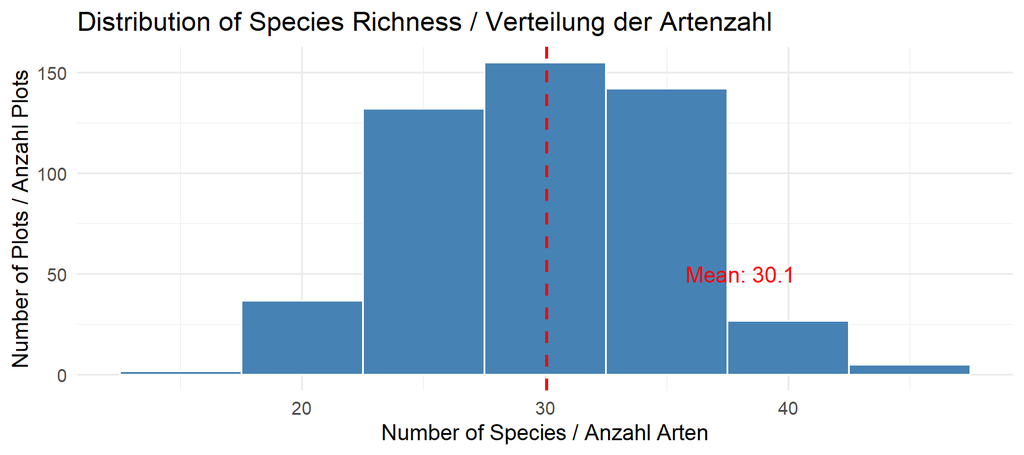

## Preparing Data: Native vs. AlienDaten vorbereiten: Heimisch vs. Alien

### Step 1: Separate datasets

```r
# Keep only native species
native_data <- data[data$status == "native", ]

# Keep only alien species
alien_data <- data[data$status == "alien", ]

# Check
nrow(native_data)
nrow(alien_data)
```

### Step 2: Check sample sizes

```r
# How many plots contain at least one native species?
plots_with_native <- length(unique(native_data$plot_id))

# How many plots contain at least one alien species?
plots_with_alien <- length(unique(alien_data$plot_id))

print(paste("Plots with Native:", plots_with_native))
print(paste("Plots with Alien:", plots_with_alien))
```

**Discussion:** Is the comparison fair if we have fewer alien plots?

### Schritt 1: Datensatze trennen

```r
# Nur heimische Arten behalten
native_daten <- daten[daten$status == "native", ]

# Nur alien Arten behalten
alien_daten <- daten[daten$status == "alien", ]

# Kontrolle
nrow(native_daten)
nrow(alien_daten)
```

### Schritt 2: Stichprobengrossen prufen

```r
# Wie viele Plots enthalten mindestens eine heimische Art?
plots_mit_native <- length(unique(native_daten$plot_id))

# Wie viele Plots enthalten mindestens eine alien Art?
plots_mit_alien <- length(unique(alien_daten$plot_id))

print(paste("Plots mit Native:", plots_mit_native))
print(paste("Plots mit Alien:", plots_mit_alien))
```

**Diskussion:** Ist der Vergleich fair, wenn wir viel weniger Alien-Plots haben?

# Part 6: Analysis & InterpretationTeil 6: Analyse & Interpretation

## Multiple Starting PointsMultiple Startpunkte

### The Problem of Randomness

**Problem:** The starting point massively influences the curve!

- Different start = different route
- Different route = different curve
- **Solution:** Try many starting points and average

### Das Problem der Zufalligkeit

**Problem:** Der Startpunkt beeinflusst die Kurve massiv!

- Unterschiedlicher Start = unterschiedliche Route
- Unterschiedliche Route = unterschiedliche Kurve
- **Losung:** Viele Startpunkte ausprobieren und mitteln

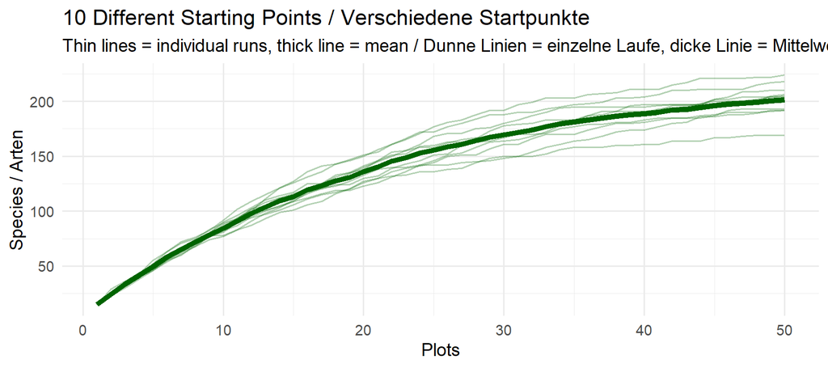

## Confidence IntervalsKonfidenzintervalle

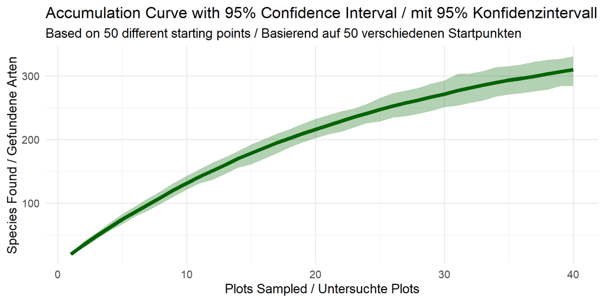

**What does the 95% confidence interval mean?**

- We are 95% confident the “true” value lies in this range
- Wide interval = much uncertainty
- Narrow interval = precise estimate

**Was bedeutet das 95% Konfidenzintervall?**

- Wir sind zu 95% sicher, dass der “wahre” Wert in diesem Bereich liegt
- Breites Intervall = viel Unsicherheit
- Schmales Intervall = prazise Schatzung

## Final Comparison: Native vs. AlienFinaler Vergleich: Heimisch vs. Alien

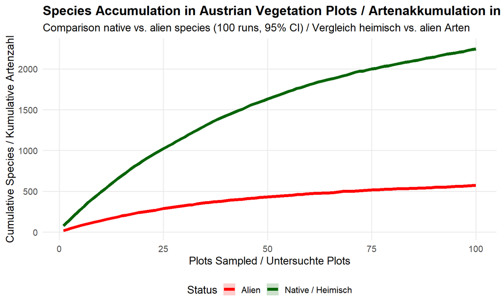

## What Do the Curves Tell Us?Was sagen uns die Kurven?

| Observation | Meaning |
| --- | --- |
| Native: Higher asymptote | More native species overall in Austria |
| Native: Steeper rise | Native species discovered faster |
| Alien: Flatter curve | Fewer alien species in total pool |
| Alien: Earlier saturation | Alien species more spatially concentrated |
| Different CI width | Different spatial variability |

| Beobachtung | Bedeutung |
| --- | --- |
| Heimisch: Hohere Asymptote | Mehr heimische Arten insgesamt in Osterreich |
| Heimisch: Steilerer Anstieg | Heimische Arten werden schneller entdeckt |
| Alien: Flachere Kurve | Weniger Alien-Arten im Gesamtpool |
| Alien: Fruhere Sattigung | Alien-Arten raumlich konzentrierter |
| Unterschiedliche CI-Breite | Unterschiedliche raumliche Variabilitat |

## Biological InterpretationBiologische Interpretation

| Pattern | Possible Explanation |
| --- | --- |
| Aliens flatter | Fewer alien species overall |
| Aliens steeper at start | Aliens concentrated in certain habitats |
| Aliens flatter at end | Faster saturation due to smaller species pool |
| Same shape | Similar spatial distribution patterns |
| Higher variance in aliens | Stronger spatial clustering |

**Discussion:** Which pattern do we expect based on invasion biology?

| Muster | Mogliche Erklarung |
| --- | --- |
| Aliens flacher | Weniger Alien-Arten insgesamt |
| Aliens steiler am Anfang | Aliens konzentriert in bestimmten Habitaten |
| Aliens flacher am Ende | Schnellere Sattigung durch kleineren Artenpool |
| Gleiche Form | Ahnliche raumliche Verteilungsmuster |
| Hohere Varianz bei Aliens | Starkeres raumliches Clustering |

**Diskussion:** Welches Muster erwarten wir basierend auf der Invasionsbiologie?

## Discussion: MechanismsDiskussion: Mechanismen

**What could explain the different accumulation patterns?**

1. **Species pool size**
   - Simply fewer alien than native species
   - Historical: Natives had millennia to evolve
2. **Spatial distribution**
   - Aliens concentrated at entry points (cities, traffic routes)
   - Natives more evenly distributed
3. **Habitat specialization**
   - Aliens restricted to few habitat types
   - Natives in all habitats
4. **Invasion stage**
   - Some aliens only recently established
   - Not yet fully spread

**Which explanation is most likely? How could we test it?**

**Was konnte die unterschiedliche Akkumulation erklaren?**

1. **Artenpool-Grosse**
   - Einfach weniger Alien- als heimische Arten
   - Historisch: Heimische hatten Jahrtausende Zeit
2. **Raumliche Verteilung**
   - Aliens konzentriert an Eintrittspforten (Stadte, Verkehrswege)
   - Heimische gleichmassiger verteilt
3. **Habitat-Spezialisierung**
   - Aliens auf wenige Habitattypen beschrankt
   - Heimische in allen Habitaten
4. **Invasions-Stadium**
   - Manche Aliens erst seit kurzem etabliert
   - Noch nicht vollstandig ausgebreitet

**Welche Erklarung ist am wahrscheinlichsten? Wie konnten wir das testen?**

## LimitationsLimitationen

**What have we NOT considered?**

| Limitation | Consequence | Possible Solution |
| --- | --- | --- |
| **Temporal dynamics** | Aliens might be more frequent in newer plots | Filter plots by year |
| **Habitat types** | Some habitats have more aliens | Stratify by habitat |
| **Detectability** | Some species harder to find | Rarefaction curves |
| **Sampling bias** | Some regions overrepresented | Spatially stratified sampling |
| **Plot size** | Different plot sizes | Standardize by area |

**Which limitation is most problematic for our conclusions?**

**Was haben wir NICHT berucksichtigt?**

| Limitation | Konsequenz | Mogliche Losung |
| --- | --- | --- |
| **Zeitliche Dynamik** | Aliens konnten in neueren Plots haufiger sein | Plots nach Jahr filtern |
| **Habitattypen** | Manche Habitate haben mehr Aliens | Nach Habitat stratifizieren |
| **Detektierbarkeit** | Manche Arten schwerer zu finden | Rarefaction curves |
| **Sampling Bias** | Manche Regionen uberreprasentiert | Raumlich stratifiziertes Sampling |
| **Plot-Grosse** | Unterschiedliche Plotgrossen | Auf Flache standardisieren |

**Welche Limitation ist am problematischsten fur unsere Schlussfolgerungen?**

## Conservation ImplicationsNaturschutz-Implikationen

**What do our results mean for conservation?**

If aliens show lower diversity: - Low threat to native diversity? - Or only problematic in certain habitats?

If aliens are spatially clustered: - Focused control possible? - Early detection at hotspots?

**Caution with conclusions:** - Our analysis shows PATTERNS, not PROCESSES - Correlation =/= Causation - Need experimental data for management decisions

**Was bedeuten unsere Ergebnisse fur den Naturschutz?**

Wenn Aliens niedrigere Diversitat zeigen: - Geringe Bedrohung fur native Diversitat? - Oder nur in bestimmten Habitaten problematisch?

Wenn Aliens raumlich geclustert sind: - Fokussierte Bekampfung moglich? - Fruherkennung an Hotspots?

**Vorsicht mit Schlussfolgerungen:** - Unsere Analyse zeigt MUSTER, nicht PROZESSE - Korrelation =/= Kausalitat - Brauchen experimentelle Daten fur Management-Entscheidungen

# Summary: What We LearnedZusammenfassung: Was wir gelernt haben

## Key Concepts from Day 2

- **Building accumulation curves** step by step in R
- **Nearest Neighbour algorithm** for spatial ordering
- **EVA database** - real Austrian vegetation data
- **Filtering data** by status (native vs. alien)
- **Multiple starting points** to account for randomness
- **Confidence intervals** to visualize uncertainty
- **Interpretation** of curve patterns

## Take-Home Message

Accumulation curves are powerful tools to understand biodiversity patterns and compare species groups. But always consider: - The method matters (random vs. nearest neighbour) - Uncertainty is real (use confidence intervals) - Patterns suggest hypotheses, not definitive answers

## Kernkonzepte von Tag 2

- **Akkumulationskurven bauen** Schritt fur Schritt in R
- **Nearest Neighbour Algorithmus** fur raumliche Ordnung
- **EVA-Datenbank** - echte osterreichische Vegetationsdaten
- **Daten filtern** nach Status (heimisch vs. alien)
- **Multiple Startpunkte** um Zufalligkeit zu berucksichtigen
- **Konfidenzintervalle** um Unsicherheit zu visualisieren
- **Interpretation** von Kurvenmustern

## Take-Home Message

Akkumulationskurven sind machtige Werkzeuge um Biodiversitatsmuster zu verstehen und Artengruppen zu vergleichen. Aber immer bedenken: - Die Methode ist wichtig (zufallig vs. nearest neighbour) - Unsicherheit ist real (Konfidenzintervalle nutzen) - Muster deuten Hypothesen an, keine definitiven Antworten

# Appendix: R Code ReferenceAnhang: R Code Referenz

## Essential Functions

| Function | Purpose |
| --- | --- |
| `unique()` | Get unique values |
| `length()` | Count elements |
| `setdiff()` | Find elements in A but not in B |
| `cumsum()` | Cumulative sum |
| `sqrt()` | Square root |
| `which.min()` | Index of minimum value |
| `subset()` | Filter data |
| `ggplot()` | Create visualizations |
| `geom_line()` | Line plot |
| `geom_ribbon()` | Confidence band |

## Useful Patterns

```r
# Cumulative species count
cumsum(c(10, 5, 3, 2, 1))

# Find new species
new <- setdiff(plot_species, found_species)

# Calculate distance
sqrt((x2 - x1)^2 + (y2 - y1)^2)

# Filter by condition
data[data$status == "native", ]
```

## Wichtige Funktionen

| Funktion | Zweck |
| --- | --- |
| `unique()` | Einzigartige Werte |
| `length()` | Elemente zahlen |
| `setdiff()` | Elemente in A aber nicht in B |
| `cumsum()` | Kumulative Summe |
| `sqrt()` | Quadratwurzel |
| `which.min()` | Index des Minimums |
| `subset()` | Daten filtern |
| `ggplot()` | Visualisierungen |
| `geom_line()` | Linienplot |
| `geom_ribbon()` | Konfidenzband |

## Nutzliche Muster

```r
# Kumulative Artenzahl
cumsum(c(10, 5, 3, 2, 1))

# Neue Arten finden
neue <- setdiff(plot_arten, gefundene_arten)

# Distanz berechnen
sqrt((x2 - x1)^2 + (y2 - y1)^2)

# Nach Bedingung filtern
daten[daten$status == "native", ]
```